# Analysis VM results Namibia data

Alejandrina Cristia

2/21/2018

## Key outcomes

- LDC outperforms OpenSat
- overall performance for SAD looks ok, for DiarTK dismal – but may relate to databsae coding

*To do’s*

- URGENT add clip identity
- For evaluation of diartk in Namibia data, merge C1 and C2, F2 and F3, M1 and M2. Might need to also change the procedure.
- see what may explain variance between clips: overall sound, number of turns, presence of background noise,..
- also, check that the right speakers are being considered (ie not LF2P, noise)

*Questions*

- why so many (34%) files with DER above 100%?
- Is performance systematically above .5 B3F1 for SAD related to a chance level?

## First description

```r
table(alltools$method)
```

```
##
##        diartk           ldc   openSat_Sum openSat_noSum
##           976          1081           978           978
```

```r
summary(alltools$DER)
```

```
##    Min. 1st Qu.  Median    Mean 3rd Qu.    Max.
##    0.00   65.93   90.93  106.38  110.60 3298.96
```

```r
alltools$DER[alltools$DER>100]<-NA

summary(alltools$B3F1)
```

```
##    Min. 1st Qu.  Median    Mean 3rd Qu.    Max.
##  0.2252  0.5482  0.6243  0.6192  0.6894  1.0000
```

```r
summary(alltools$MI)
```

```
##     Min.  1st Qu.   Median     Mean  3rd Qu.     Max.
## 0.000000 0.008839 0.048186 0.122271 0.164402 1.551829
```

LDC has analyzed 1081 segments, whereas opensat managed 978. The fact that the number for diartk is lower probably relates to the fact that only segments with some speech get analyzed.

As usual, DER returns some ridiculous values. Since DER is a rate, it should go from 0 to 100. We NA values above 100, namely 34% of the values.

There is nothing to be said of B3 F1. It goes from 0 to 1, as it should.

I don’t know enough about MI to say much about it, except that there seem to be some outlier values.

## Speech activity detection

3 options: opensat no sum, opensat sum, ldc

### overall performance

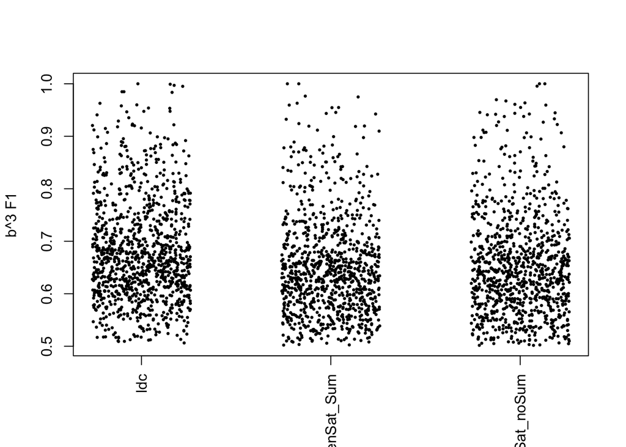

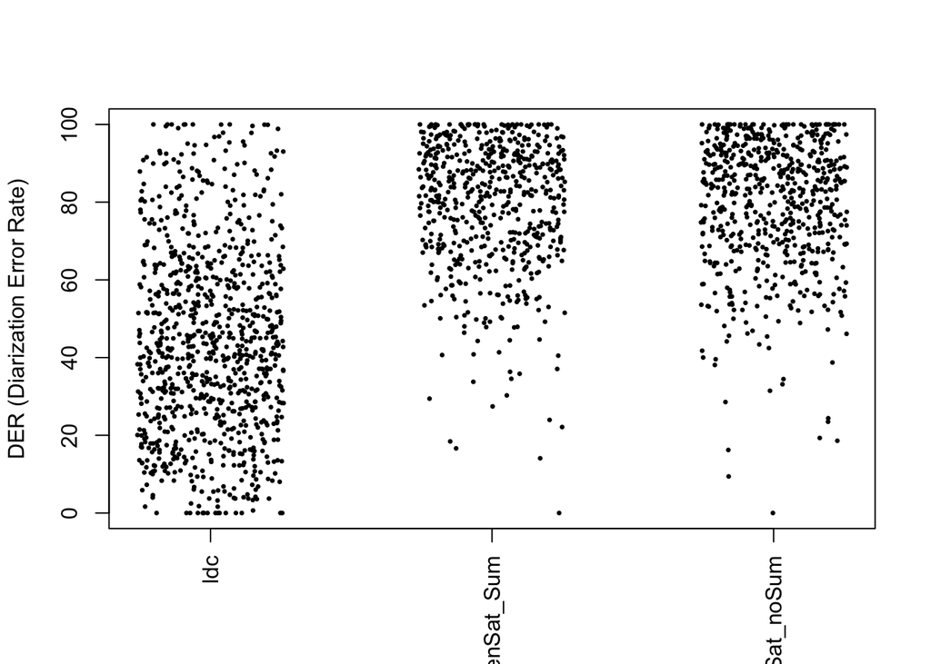

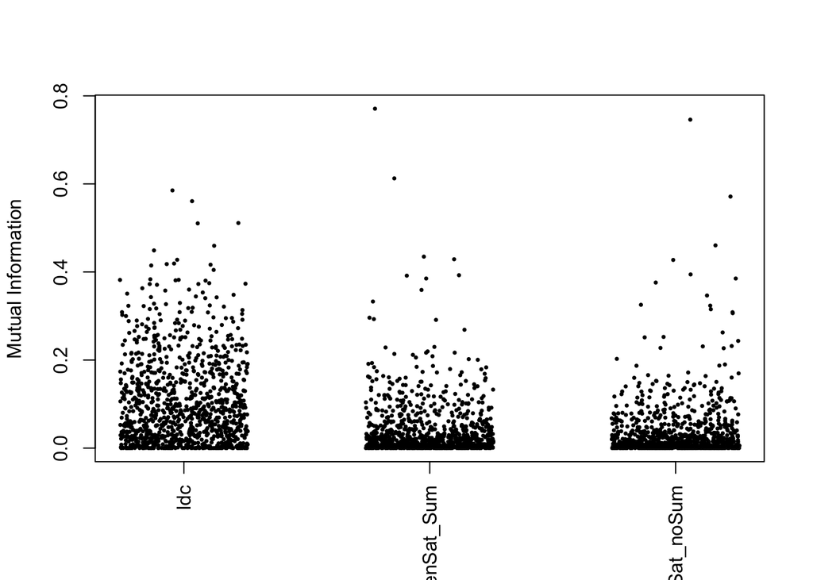

### direct comparison for individual recordings CANNOT BE DONE BECAUSE OUTPUT DOESN’T CONTAIN CLIP NAME

### Statistical comparison

The following regression does not take into account repeated measures, which could change results making them more stark, or by losing significance. It is unlikely that this will change the fact that there is a slight trend towards lower performance for openSat than ldc.

```
##
## Call:
## lm(formula = B3F1 ~ method, data = sad)
##
## Residuals:
##      Min       1Q   Median       3Q      Max
## -0.17397 -0.06646 -0.01473  0.04707  0.35028
##
## Coefficients:
##                      Estimate Std. Error t value Pr(>|t|)
## (Intercept)          0.680258   0.002881 236.096  < 2e-16 ***
## methodopenSat_Sum   -0.030538   0.004181  -7.305 3.54e-13 ***
## methodopenSat_noSum -0.027270   0.004181  -6.523 8.05e-11 ***
## ---
## Signif. codes:  0 '***' 0.001 '**' 0.01 '*' 0.05 '.' 0.1 ' ' 1
##
## Residual standard error: 0.09473 on 3034 degrees of freedom
## Multiple R-squared:  0.0211, Adjusted R-squared:  0.02045
## F-statistic:  32.7 on 2 and 3034 DF,  p-value: 8.926e-15
```

```
##
## Call:
## lm(formula = DER ~ method, data = sad)
##
## Residuals:
##     Min      1Q  Median      3Q     Max
## -79.259 -12.925   1.285  13.680  56.095
##
## Coefficients:
##                     Estimate Std. Error t value Pr(>|t|)
## (Intercept)          43.9047     0.6639   66.13   <2e-16 ***
## methodopenSat_Sum    34.9898     1.0642   32.88   <2e-16 ***
## methodopenSat_noSum  35.3542     1.0402   33.99   <2e-16 ***
## ---
## Signif. codes:  0 '***' 0.001 '**' 0.01 '*' 0.05 '.' 0.1 ' ' 1
##
## Residual standard error: 20.12 on 2131 degrees of freedom
##   (903 observations deleted due to missingness)
## Multiple R-squared:  0.4288, Adjusted R-squared:  0.4283
## F-statistic: 799.9 on 2 and 2131 DF,  p-value: < 2.2e-16
```

```
##
## Call:
## lm(formula = MI ~ method, data = sad)
##
## Residuals:
##      Min       1Q   Median       3Q      Max
## -0.10268 -0.03498 -0.02294  0.01983  0.73191
##
## Coefficients:
##                      Estimate Std. Error t value Pr(>|t|)
## (Intercept)          0.102682   0.002353   43.64   <2e-16 ***
## methodopenSat_Sum   -0.063762   0.003414  -18.68   <2e-16 ***
## methodopenSat_noSum -0.067699   0.003414  -19.83   <2e-16 ***
## ---
## Signif. codes:  0 '***' 0.001 '**' 0.01 '*' 0.05 '.' 0.1 ' ' 1
##
## Residual standard error: 0.07736 on 3034 degrees of freedom
## Multiple R-squared:  0.1424, Adjusted R-squared:  0.1419
## F-statistic:   252 on 2 and 3034 DF,  p-value: < 2.2e-16
```

Next a direct comparison between the two opensat. The difference is not significant, and numerically very small. Taking into account repeated measures would be important.

```
##
##  Welch Two Sample t-test
##
## data:  B3F1 by method
## t = -0.76969, df = 1948.9, p-value = 0.4416
## alternative hypothesis: true difference in means is not equal to 0
## 95 percent confidence interval:
##  -0.011594640  0.005058772
## sample estimates:
##   mean in group openSat_Sum mean in group openSat_noSum
##                   0.6497200                   0.6529879
```

```
##
##  Welch Two Sample t-test
##
## data:  DER by method
## t = -0.38522, df = 1207.2, p-value = 0.7001
## alternative hypothesis: true difference in means is not equal to 0
## 95 percent confidence interval:
##  -2.220224  1.491444
## sample estimates:
##   mean in group openSat_Sum mean in group openSat_noSum
##                    78.89456                    79.25895
```

```
##
##  Welch Two Sample t-test
##
## data:  MI by method
## t = 1.3853, df = 1952, p-value = 0.1661
## alternative hypothesis: true difference in means is not equal to 0
## 95 percent confidence interval:
##  -0.001636617  0.009511004
## sample estimates:
##   mean in group openSat_Sum mean in group openSat_noSum
##                  0.03891989                  0.03498270
```

## Diarization

This dataset is not good for diarization because C1 and C2, F2 and F3, and M1 and M2 are interchangeable. Nonetheless, for what it’s worth, here are the results.

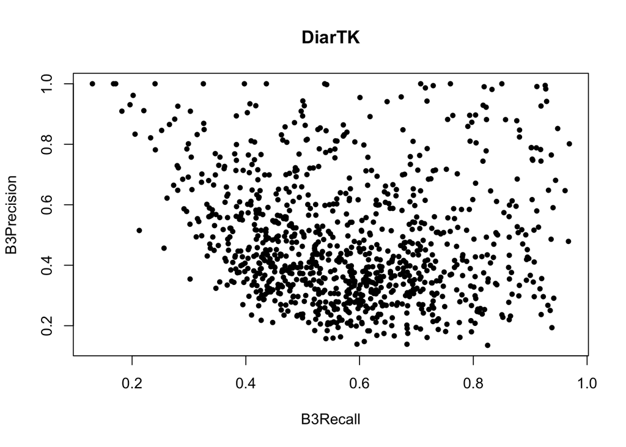

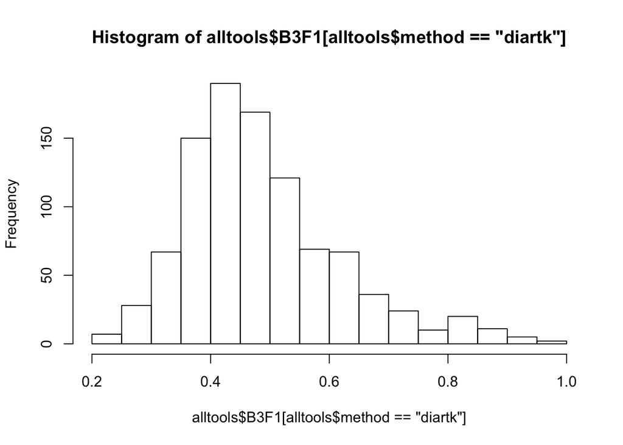

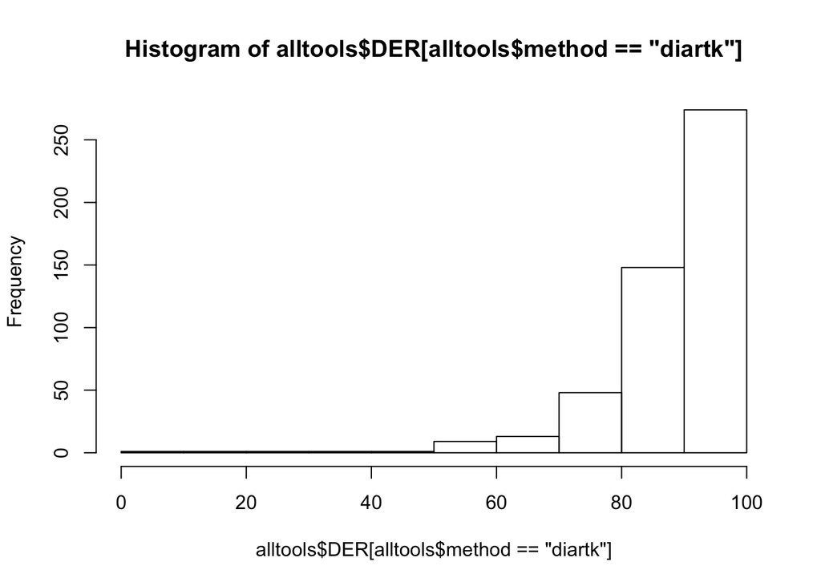

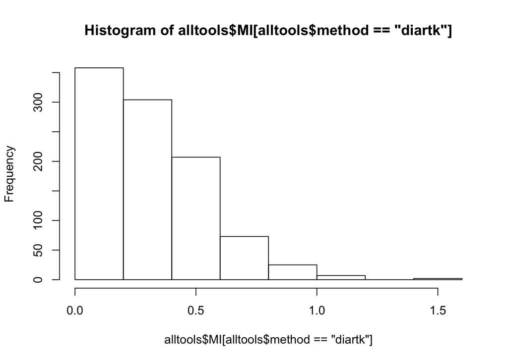